# Ggplot2 Overview

# Getting started

## Getting started with ggplot2

In this chapter we’ll mostly use one data set that’s bundled with ggplot2: mpg . It includes information about the fuel economy of popular car models in 1999 and 2008, collected by the US Environment Protection Agency.

You can access the data by loading ggplot2

```r
library(ggplot2)
mpg
```

| manufacturer | model | displ | year | cyl | trans | drv | cty | hwy | fl | class |
| --- | --- | --- | --- | --- | --- | --- | --- | --- | --- | --- |
| audi | a4 | 1.8 | 1999 | 4 | auto(l5) | f | 18 | 29 | p | compact |
| audi | a4 | 1.8 | 1999 | 4 | manual(m5) | f | 21 | 29 | p | compact |
| audi | a4 | 2.0 | 2008 | 4 | manual(m6) | f | 20 | 31 | p | compact |
| audi | a4 | 2.0 | 2008 | 4 | auto(av) | f | 21 | 30 | p | compact |
| audi | a4 | 2.8 | 1999 | 6 | auto(l5) | f | 16 | 26 | p | compact |
| audi | a4 | 2.8 | 1999 | 6 | manual(m5) | f | 18 | 26 | p | compact |
| audi | a4 | 3.1 | 2008 | 6 | auto(av) | f | 18 | 27 | p | compact |
| audi | a4 quattro | 1.8 | 1999 | 4 | manual(m5) | 4 | 18 | 26 | p | compact |
| audi | a4 quattro | 1.8 | 1999 | 4 | auto(l5) | 4 | 16 | 25 | p | compact |
| audi | a4 quattro | 2.0 | 2008 | 4 | manual(m6) | 4 | 20 | 28 | p | compact |

[output cut: 224 more lines]

Every ggplot2 plot has three key components:

1. **data**,
2. A set of **aesthetic mappings** between variables in the data and visual properties, and
3. At least one layer which describes how to render each observation. Layers are usually created with a **geom function**.

Here’s a simple example:

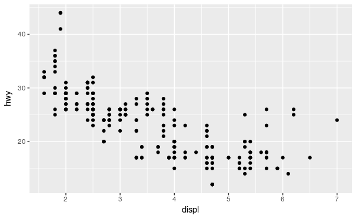

```r
ggplot(mpg, aes(x = displ, y = hwy)) +
    geom_point()
```

Almost every plot maps a variable to x and y , so naming these aesthetics is tedious, and first two unnamed arguments to aes() will be mapped to x and y . That means that following code is identical to the example above:

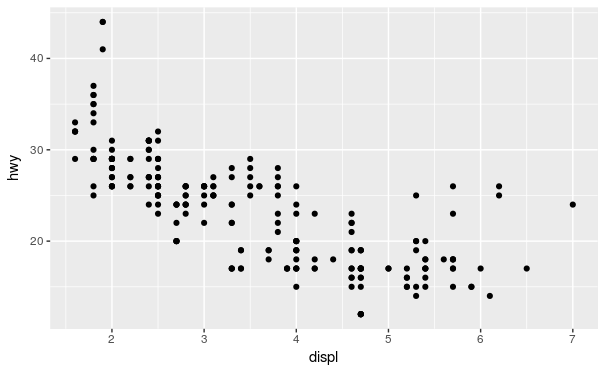

```r
ggplot(mpg, aes(displ, hwy)) +
  geom_point()
```

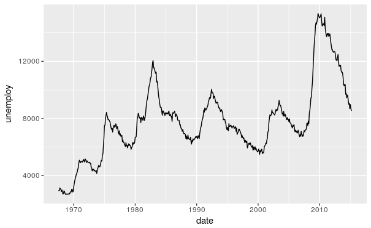

```r
ggplot(economics, aes(date, unemploy)) + geom_line()
```

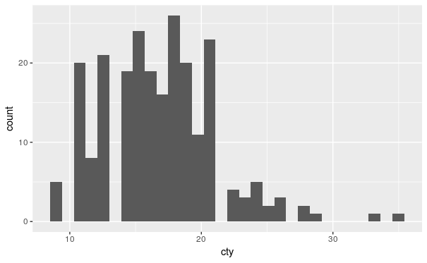

```r
ggplot(mpg, aes(cty)) + geom_histogram()
```

### Colour, size, shape and other aesthetic attributes

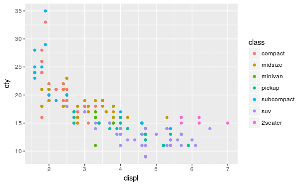

```r
ggplot(mpg, aes(displ, cty, colour = class)) +
  geom_point()
```

If you want to set an aesthetic to a fixed value, without scaling it, do so in the individual layer outside of aes() . Compare the following two plots:

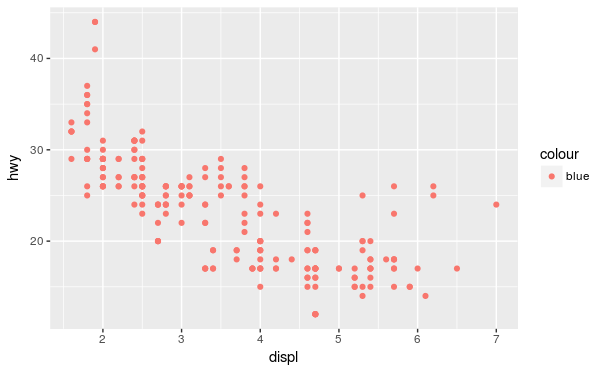

```r
ggplot(mpg, aes(displ, hwy)) + geom_point(aes(colour = "blue"))
```

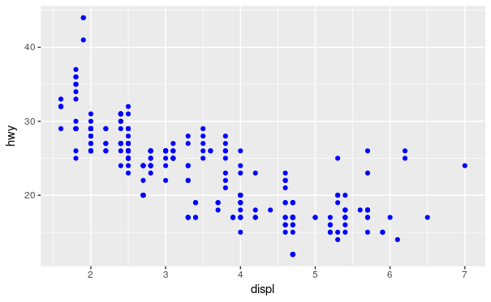

```r
ggplot(mpg, aes(displ, hwy)) + geom_point(colour = "blue")
```

### Faceting

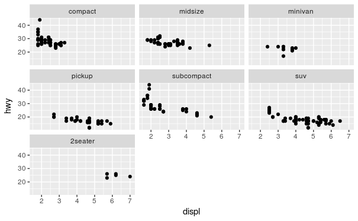

```r
ggplot(mpg, aes(displ, hwy)) +
geom_point() +
facet_wrap(~class)
```

### Plot geoms

You might guess that by substituting geom_point() for a different geom func- tion, you’d get a different type of plot:

- **geom_smooth()** fits a smoother to the data and displays the smooth and its standard error.
- **geom_boxplot()** produces a box-and-whisker plot to summarise the distri- bution of a set of points.
- **geom_histogram()** and **geom_freqpoly()** show the distribution of continuous variables.
- **geom_bar()** shows the distribution of categorical variables.
- **geom_path()** and geom_line() draw lines between the data points. A line plot is constrained to produce lines that travel from left to right, while paths can go in any direction.

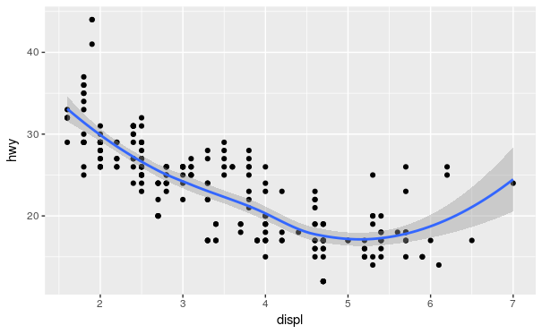

```r
ggplot(mpg, aes(displ, hwy)) +
geom_point() +
geom_smooth()
```

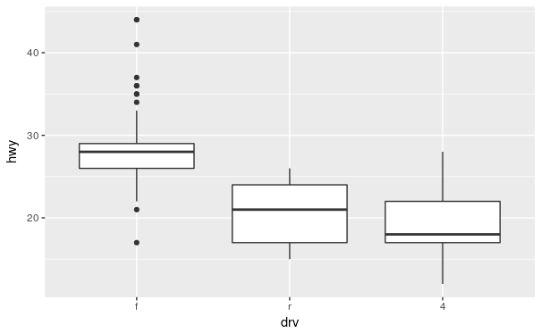

```r
ggplot(mpg, aes(drv, hwy)) + geom_boxplot()
```

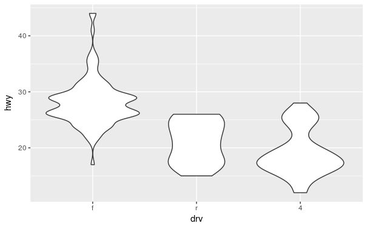

```r
ggplot(mpg, aes(drv, hwy)) + geom_violin()
```

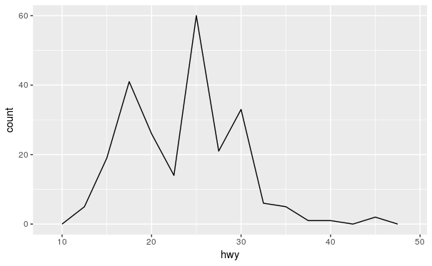

```r
ggplot(mpg, aes(hwy)) +
geom_freqpoly(binwidth = 2.5)
```

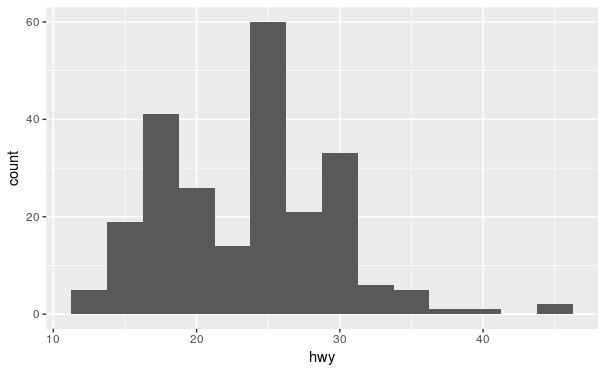

```r
ggplot(mpg, aes(hwy)) +
geom_histogram(binwidth = 2.5)
```

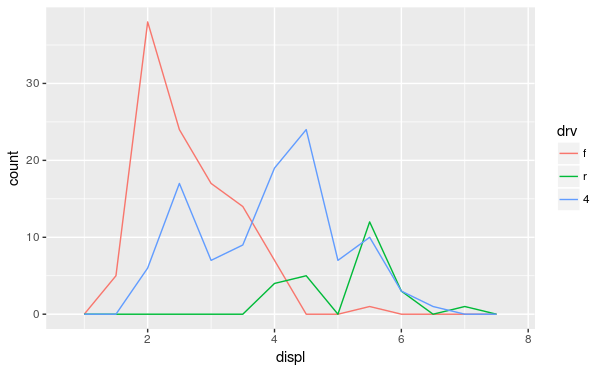

```r
ggplot(mpg, aes(displ, colour = drv)) +
geom_freqpoly(binwidth = 0.5)
```

### Time series with line and path plots

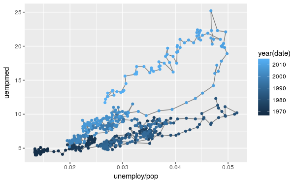

```r
year <- function(x) as.POSIXlt(x)$year + 1900
ggplot(economics, aes(unemploy / pop, uempmed)) +
geom_path(colour = "grey50") +
geom_point(aes(colour = year(date)))
```

### Modifying the axes

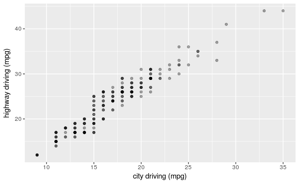

```r
ggplot(mpg, aes(cty, hwy)) +
geom_point(alpha = 1 / 3) +
xlab("city driving (mpg)") +
ylab("highway driving (mpg)")
```

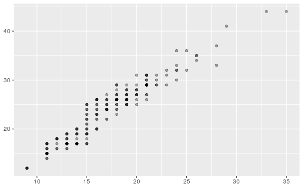

```r
# Remove the axis labels with NULL
ggplot(mpg, aes(cty, hwy)) +
geom_point(alpha = 1 / 3) +
xlab(NULL) +
ylab(NULL)
```